# Causal Inference on Diabetes Risk

Author

Michael Callahan

## Background

We were hired by the NIH to identify biomarkers that act as indicators of diabetes risk. Specifically, we were asked whether blood glucose (`glucose`) alone, blood insulin levels (`insulin`) alone, or both of them together is the best indicator of whether or not someone has diabetes. Rather than develop a statistical model, our clients at the NIH want us to perform this analysis using visualizations only.

## Data inspection

We were given access to a case-control data set (mix of diabetes and non-diabetes patients) with a number of biomarkers recorded for each patient. Here, we can take a look at the top several rows:

```r
head(data)
```

| Pregnancies | Glucose | BloodPressure | SkinThickness | Insulin | BMI | DiabetesPedigreeFunction | Age | Outcome |
| --- | --- | --- | --- | --- | --- | --- | --- | --- |
| 6 | 148 | 72 | 35 | 0 | 33.6 | 0.627 | 50 | 1 |
| 1 | 85 | 66 | 29 | 0 | 26.6 | 0.351 | 31 | 0 |
| 8 | 183 | 64 | 0 | 0 | 23.3 | 0.672 | 32 | 1 |
| 1 | 89 | 66 | 23 | 94 | 28.1 | 0.167 | 21 | 0 |
| 0 | 137 | 40 | 35 | 168 | 43.1 | 2.288 | 33 | 1 |
| 5 | 116 | 74 | 0 | 0 | 25.6 | 0.201 | 30 | 0 |

Notably, we can see that `diabetes` is coded as a **1 (diabetes)** or a **0 (no diabetes)**. We can also take a look at the variables summaries below:

```r
summary_df <- data.frame(
  Min = sapply(data, min, na.rm = TRUE),
  Max = sapply(data, max, na.rm = TRUE),
  Mean = sapply(data, mean, na.rm = TRUE),
  Median = sapply(data, median, na.rm = TRUE)
)
summary_df
```

|  | Min | Max | Mean | Median |
| --- | --- | --- | --- | --- |
| Pregnancies | 0.000 | 17.00 | 3.8450521 | 3.0000 |
| Glucose | 0.000 | 199.00 | 120.8945312 | 117.0000 |
| BloodPressure | 0.000 | 122.00 | 69.1054688 | 72.0000 |
| SkinThickness | 0.000 | 99.00 | 20.5364583 | 23.0000 |
| Insulin | 0.000 | 846.00 | 79.7994792 | 30.5000 |
| BMI | 0.000 | 67.10 | 31.9925781 | 32.0000 |
| DiabetesPedigreeFunction | 0.078 | 2.42 | 0.4718763 | 0.3725 |
| Age | 21.000 | 81.00 | 33.2408854 | 29.0000 |
| Outcome | 0.000 | 1.00 | 0.3489583 | 0.0000 |

Here, we can see that `insulin` is significantly more right-skewed than `glucose`. In order to compare the two across similar levels of variation, I will always use the logarithm of `insulin` instead of the raw data going forward.

## Data visualization

#### Each predictor vs. diabetes risk

In Figure 1, we can see a box plot of the two predictors across diabetes diagnoses:

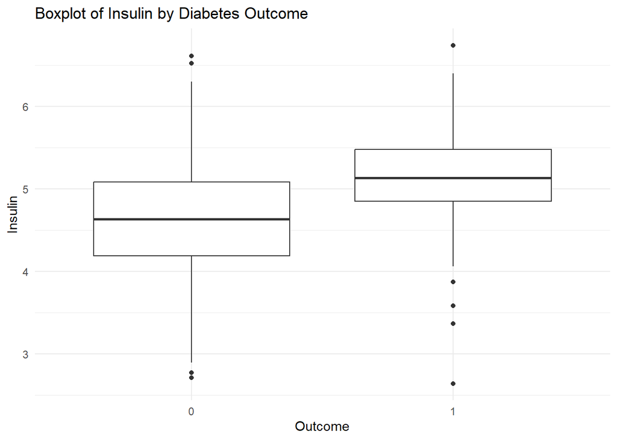

(a) Insulin vs. Diabetes Risk

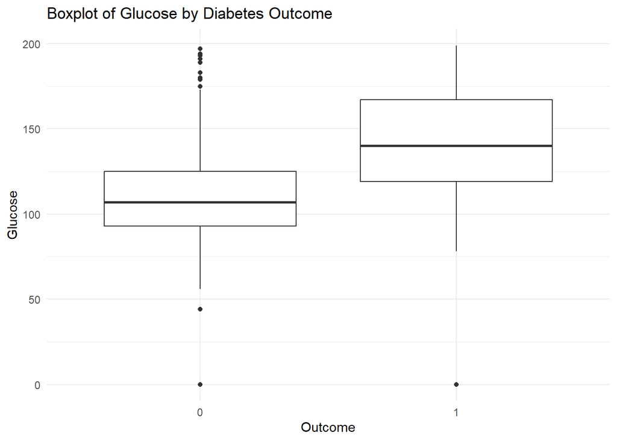

(b) Glucose vs. Diabetes Risk

Figure 1: Boxplots: Each of the two predictors vs. diabetes risk

```r
# Show the relationship between Insulin and Diabetes, and Glucose and Diabetes
ggplot(data, aes(x = factor(Outcome), y = log(Insulin))) +
  geom_boxplot() +
  labs(x = "Outcome", y = "Insulin", title = "Boxplot of Insulin by Diabetes Outcome") +
  theme_minimal()

ggplot(data, aes(x = factor(Outcome), y = Glucose)) +
  geom_boxplot() +
  labs(x = "Outcome", y = "Glucose", title = "Boxplot of Glucose by Diabetes Outcome") +
  theme_minimal()
```

As we can see, people with diabetes have significantly elevated levels of both glucose and insulin. We can also look in greater detail at the precise distributions across each diagnosis:

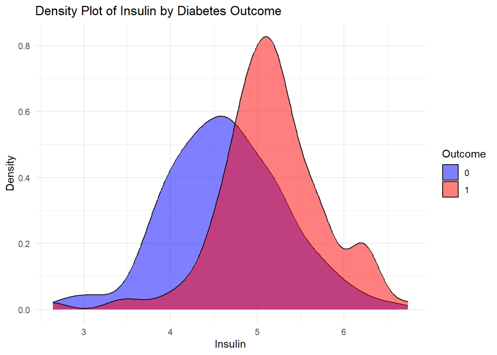

(a) Insulin vs. Diabetes Risk

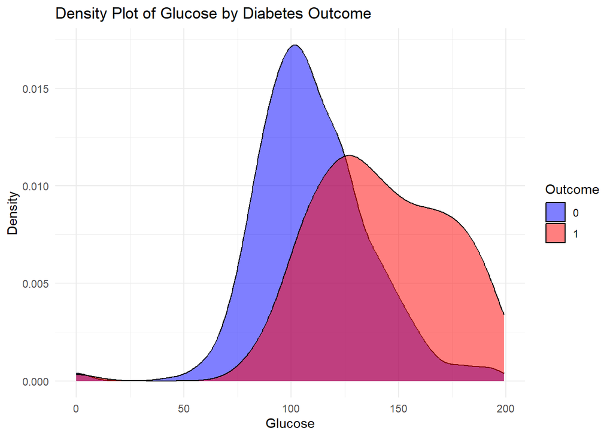

(b) Glucose vs. Diabetes Risk

```r
ggplot(data, aes(x = log(Insulin), fill = factor(Outcome))) +
  geom_density(alpha = 0.5) +
  labs(x = "Insulin", y = "Density", fill = "Outcome",
       title = "Density Plot of Insulin by Diabetes Outcome") +
  theme_minimal() +
  scale_fill_manual(values = c("0" = "blue", "1" = "red"))

ggplot(data, aes(x = Glucose, fill = factor(Outcome))) +
  geom_density(alpha = 0.5) +
  labs(x = "Glucose", y = "Density", fill = "Outcome",
       title = "Density Plot of Glucose by Diabetes Outcome") +
  theme_minimal() +
  scale_fill_manual(values = c("0" = "blue", "1" = "red"))
```

Previously, we saw that both predictors have significantly different means by diabetes diagnosis. However, here we can see that glucose stands out has having better separation between diagnoses as compared to insulin. For example, if we imagine that we observe a patient with `log(insulin) = 6` in Figure 2 (a), that person has about a 60% chance to have diabetes. However, if we observe someone with a similarly high value of `glucose = 175` in Figure 2 (b), that person has about a 90% chance to have diabetes. *Notice how having high glucose is therefore more predictive of diabetes than having high insulin, even though the difference of means is roughly the same in both predictors.*

#### Predictor multicollinearity

Of course, just because our two predictors succeed at predicting diabetes *on their own,* this does not mean that they are better when paired together. In particular, it could be possible that the two predictors are themselves correlated (multicollinearity), and that the explanatory power of one predictor is entirely spurious (coincidental), and caused by its close relationship with the other truly causal predictor. In this case, we might call the other predictor a spurious variable.

With that in mind, let’s look at the relationship between the two predictors themselves:

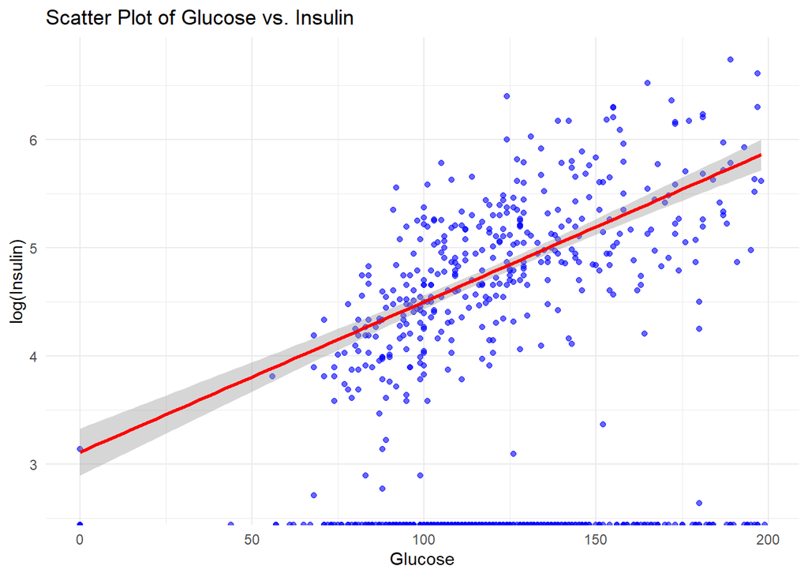

Figure 3: Predictor correlation

```r
#Show the relationship between glucose and insulin
ggplot(data, aes(x = Glucose, y = log(Insulin))) +
  geom_point(alpha = 0.6, color = "blue") +
  geom_smooth(method = "lm", color = "red", se = TRUE) +
  labs(x = "Glucose", y = "log(Insulin)",
       title = "Scatter Plot of Glucose vs. Insulin") +
  theme_minimal()
```

#### Three-way interaction

First, I aggregated the data by binning the glucose and insulin values into 3 different bins **(low=1, medium=2, high=3)**. Then summarized the data by calculating the % of diabetes of patients that fall into each of the 9 different interactive buckets. Here we can see that my smallest bin has 38 observations, which should be adequate for further analysis.

```r
#clean the data
data = data %>%
  mutate(Glucose_Quartile = ntile(Glucose, 3)) %>%
  mutate(Insulin_Quartile = ntile(Insulin, 3))

summary_data <- data %>%
  group_by(Glucose_Quartile, Insulin_Quartile) %>%
  summarise(Outcome_Percent = mean(Outcome == 1) * 100) %>%
  ungroup()

table(data$Glucose_Quartile, data$Insulin_Quartile)
```

```
      1   2   3
  1  83 135  38
  2  85  76  95
  3  88  45 123
```

Then, I plotted the diabetes rate as a function of both insulin and glucose. The two plots show the the main effect (X-axis) and secondary effect (coloring) swapped.

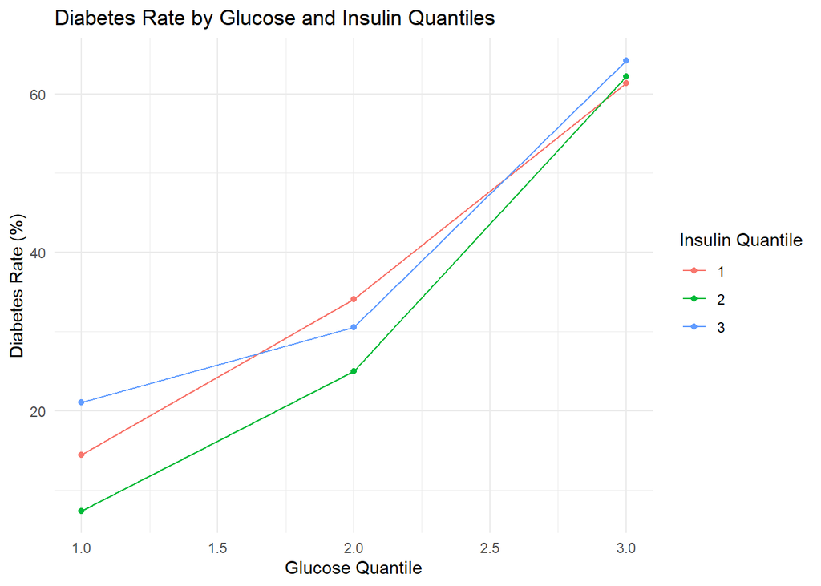

(a) Glucose as main effect

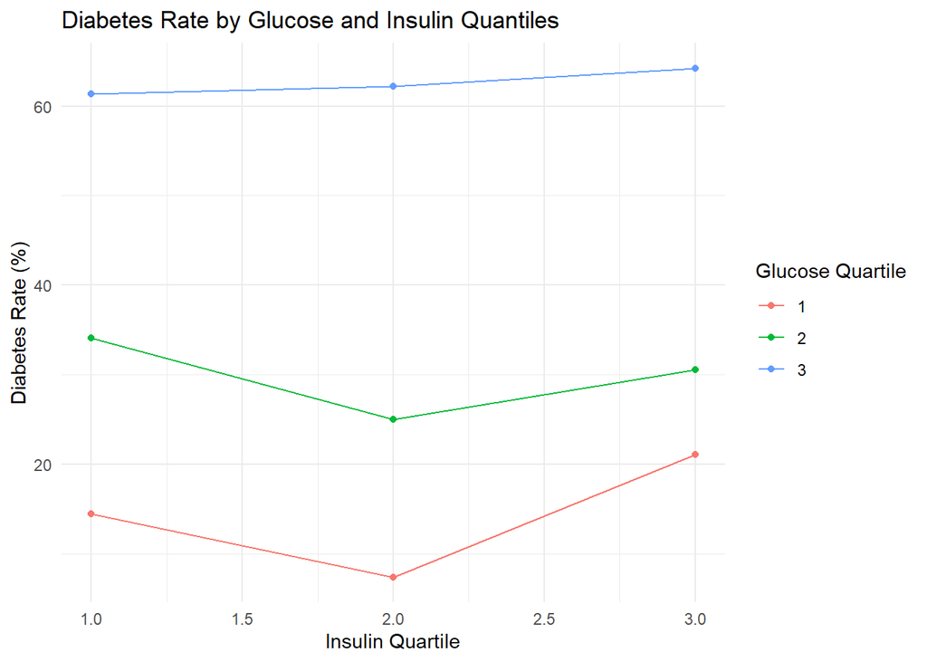

(b) Insulin as main effect

Figure 4: Three way interaction of predictors and diabetes risk

```r
# Plotting hierarchical effects of glucose & insulin on diabetes
ggplot(summary_data, aes(x = Glucose_Quartile, y = Outcome_Percent, color = factor(Insulin_Quartile))) +
  geom_line() +
  geom_point() +
  labs(x = "Glucose Quantile", y = "Diabetes Rate (%)", color = "Insulin Quantile",
       title = "Diabetes Rate by Glucose and Insulin Quantiles") +
  theme_minimal()

# Plotting hierarchical effects of insulin & glucose on diabetes
ggplot(summary_data, aes(x = Insulin_Quartile, y = Outcome_Percent, color = factor(Glucose_Quartile))) +
  geom_line() +
  geom_point() +
  labs(x = "Insulin Quartile", y = "Diabetes Rate (%)", color = "Glucose Quartile",
       title = "Diabetes Rate by Glucose and Insulin Quantiles") +
  theme_minimal()
```

Here, we can see that when we combine insulin and glucose predictors together to predict diabetes, the explanatory power is very one sided. In particular, when glucose is the main effect in Figure 4 (a), we see that moving left to right across the X-axis affects the height of the graph far more significantly than switching colors. Conversely, when insulin is the main effect in Figure 4 (b), changing color affects the diabetes rate far more significantly than moving along the X-axis. We can also see that X-axis effect in Figure 4 (b) is inconsistent moving from left to right.

## Conclusion

From our analysis, we can conclude that blood glucose is a significant, independent predictor of diabetes, whereas insulin level is only significant because of its correlation to blood glucose. As a result, the combination is likely not better than glucose alone. Therefore, we would recommend that NIH research focus more heavily on glucose monitoring for predictive research as opposed to insulin levels.